EEG · Motor State · Machine Learning

# Reading Motor State from Brain Activity

Telling apart three states — **standing**, **stepping straight**, and **stepping diagonally** — from EEG, with one model per person. A companion to the straight-vs-diagonal step-type project.

**Affiliation:** Sunnybrook Research Institute

**Date:** June 2026 · full 32-participant cohort

## 1 The short version

This is the three-way sibling of the step-type project. Instead of asking *straight or diagonal?*, it asks a broader question: **from a two-second window of EEG, can we tell whether a person is standing still, stepping straight, or stepping diagonally?** Each person gets their own model, tested only on their own held-out data.

0.88

average score (macro-AUC), where 0.50 = chance

73%

three-way accuracy (chance = 33%)

32

participants (the full cohort), each with their own model

Headline

Across all thirty-two participants, the model separates the three motor states with an average **macro-AUC of 0.878** (chance = 0.50) and **73% accuracy** (chance = 33%), and it does so honestly — the gap between its optimistic internal score and its real held-out score is tiny (0.05). **Standing is almost always identified correctly; telling a straight step from a diagonal one is the hard part.** A controlled comparison (Section 7) shows that a planned new *foot-stimulation* feature adds essentially nothing on top of the basic scalp features, while the *brain-source* feature adds a small but real boost to the hard straight-vs-diagonal distinction.

## 2 What the project is trying to do

The step-type project showed that the brain's **preparation signal** carries a faint trace of *which way* a person is about to step. This project widens the lens from two step-types to **three motor states**: standing still, stepping straight, and stepping diagonally. The motivation is the same — to read movement-related information directly from brain activity — but the three-way version is a stepping stone toward decoding a richer set of states.

Because there are now **three** possible answers, a model that guessed randomly would be right only **one third (33%)** of the time. Anything reliably above that means the EEG genuinely distinguishes the states. We keep the project's core principle: **one model per person**, each judged only on data it has never seen.

## 3 The three states and where the data come from

The data come from two separate EEG recordings per participant, which between them supply the three states. Throughout, a single **two-second slice** of the 64-sensor recording is called an **epoch** — one example the model learns from.

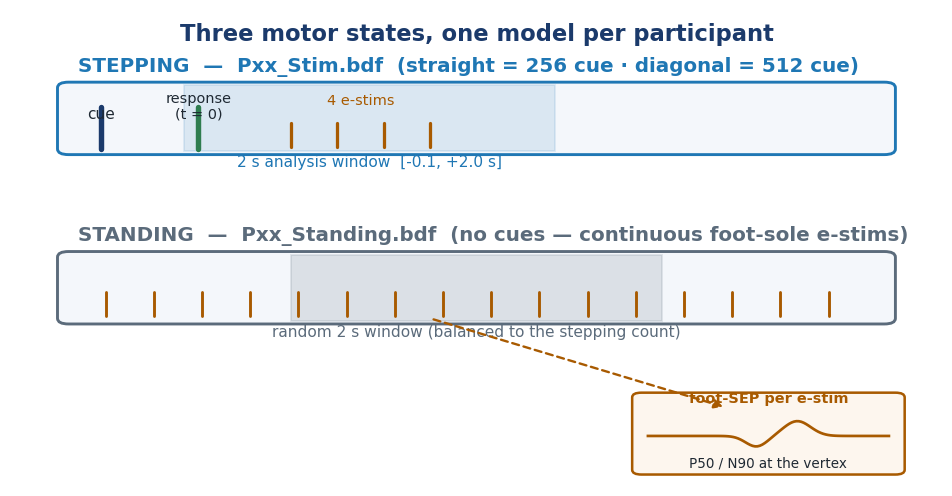

Figure 1. How the three states are defined. **Stepping** (top, from the Stim recording): after a cue tells the person which way to step, we lock a 2-second window to their response; “straight” and “diagonal” come from two different cues. **Standing** (bottom, from the Standing recording): there are no cues, so we cut random 2-second windows from the continuous recording. In *both* recordings the sole of the foot is gently electrically stimulated every half-second — the orange ticks — which evokes a tiny brain response (inset) that we turn into an optional extra feature.

- **Stepping straight / diagonal** — from the *Stim* recording. A cue tells the person the direction; about two seconds later they step. We take the 2-second window locked to their response, exactly as in the step-type project (~40 of each per person).
- **Standing** — from the *Standing* recording. Here the person simply stands; there are no cues, so we cut non-overlapping 2-second windows from the continuous recording and balance their number to the stepping trials, so the three states are evenly represented.

One quirk of this study is that throughout *both* recordings, the sole of the foot receives a gentle electrical pulse roughly twice a second. Each pulse evokes a small, brief response in the brain's sensory areas — a **somatosensory evoked potential (SEP)** — which we explored as an extra source of information (Section 5).

## 4 The prediction engine: a 3-way XGBoost model

As in the step-type project, the workhorse is **XGBoost** — a model built from many small **decision trees** (yes/no flowcharts over the measured numbers) added together, each new tree correcting the previous ones' mistakes. The only change for this project is the output: instead of one probability (“diagonal?”), the model now produces **three probabilities that add to 100%** — one for each state — and predicts whichever is largest.

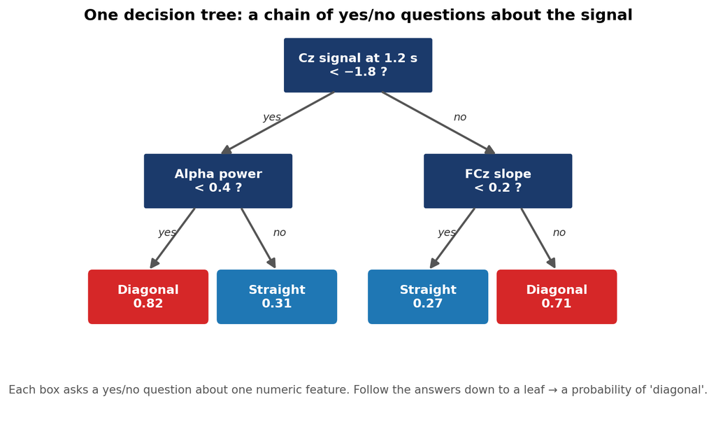

Figure 2. A single decision tree — the building block. Each box asks a yes/no question about one measurement (e.g. “was the signal at the top of the head below this level at 1.2 s?”); following the answers leads to a verdict. The model invents its own thresholds from the continuous data.

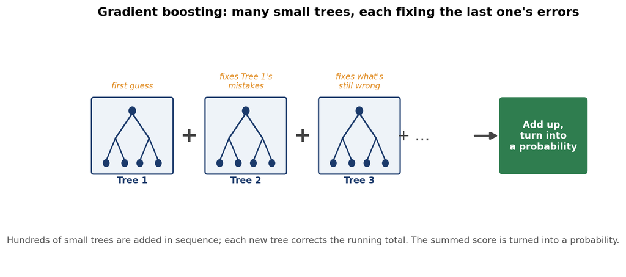

Figure 3. Gradient boosting: hundreds of simple trees are added together, each correcting the running total left by the trees before it. For this project the combined scores are turned into three competing probabilities (standing / straight / diagonal) instead of one.

Performance is summarised with **macro-AUC** — the natural three-class version of the AUC score used in the step-type report. It asks, for each state in turn, "how well does the model separate this state from the other two?", then averages. As before, **0.50 is chance and 1.00 is perfect.**

## 5 What the model looks at: the features

Each 2-second epoch is summarised into a long list of **features** — interpretable numbers describing the brain signal. We reuse the four families from the step-type project, computed by chopping the window into short **time bins** (each ~1/16<sup>th</sup> of a second):

- **Amplitude** — how high or low the signal sits at each sensor and time-slice.
- **Slopes** — whether the signal is rising or falling, and how steeply.
- **Power (frequency bands)** — the strength of the brain's rhythms (Delta…Gamma).
- **Source localisation** — an estimate (via "eLORETA") of *where* in the brain the activity arises, across ~150 regions.

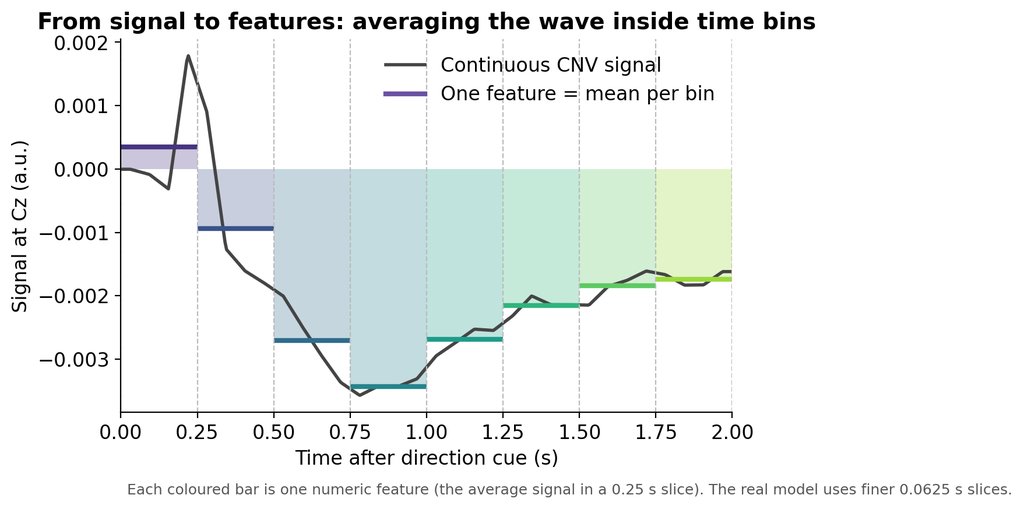

**The new ingredient — a foot-stimulation feature (“SEP”).** Because the foot is being stimulated throughout, we added a fifth, novel feature family unique to this project: for each epoch we average the tiny brain responses to the ~4 foot-pulses that fall inside it, and measure the size and timing of the two characteristic peaks (around 50 and 90 milliseconds after the pulse) over the vertex sensors. Critically, each epoch's SEP is built *only from its own pulses* — never shared across trials — so it cannot secretly leak the answer.

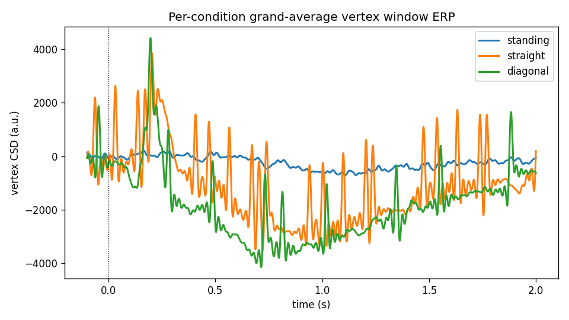

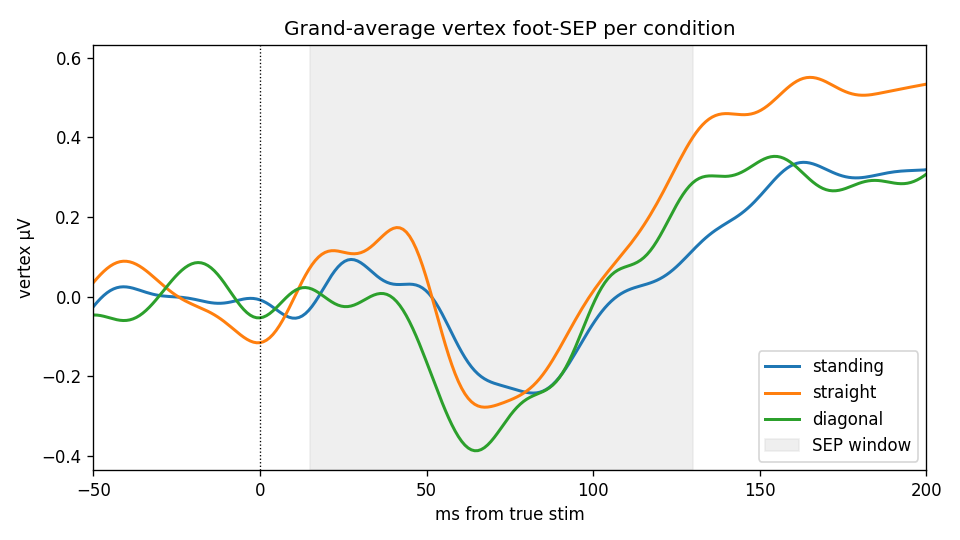

Figure 6. The foot-stimulation response (SEP) at the vertex, averaged across participants, for each state. The small deflections after the pulse are the brain's sensory response. The traces differ only modestly between states — consistent with the result (Section 7) that this feature adds little once the ordinary scalp features are present.

## 6 How the model is built and tested

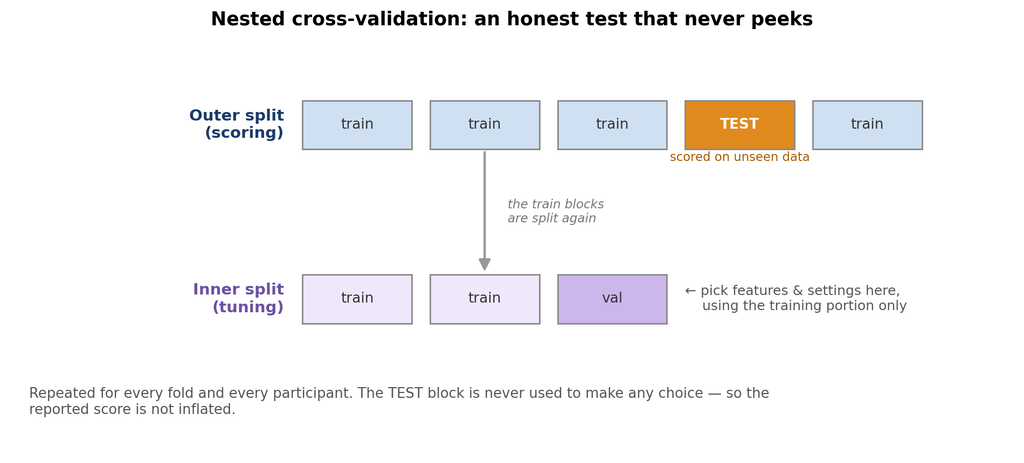

Figure 7. Nested cross-validation. An outer split sets aside a test block used only for the final score; all choices (which features to keep, which settings to use) are made on a separate inner split. Because the test block is never used to make a choice, the score is not inflated.

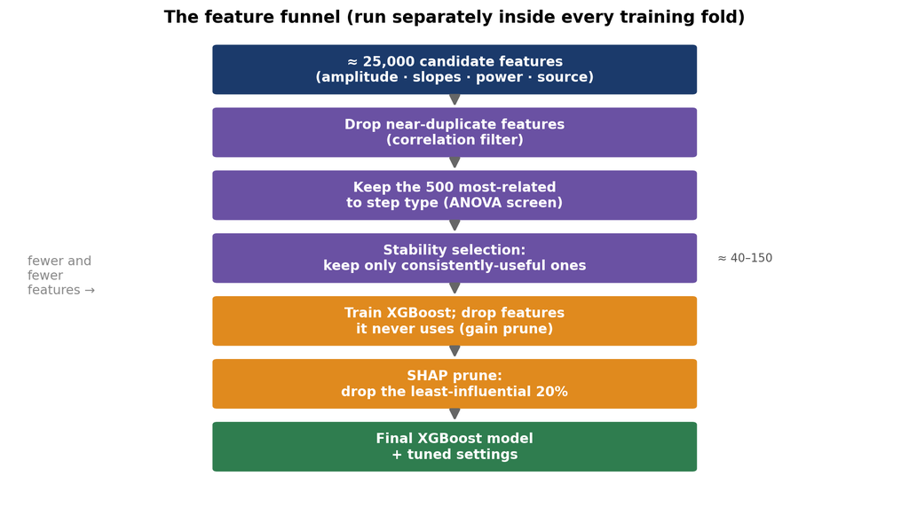

To keep the three states evenly matched, the standing windows are down-sampled to the number of stepping trials, and the cross-validation is **stratified** so every split contains all three states. Each per-person model is then scored on held-out epochs it never saw.

## 7 Results: which states are separable, and what helps

The headline numbers come from all thirty-two participants with the full honest test. To find out *which features actually matter*, we ran the same analysis four times, each time with a different feature set — an **ablation**. This is the most informative result in the report.

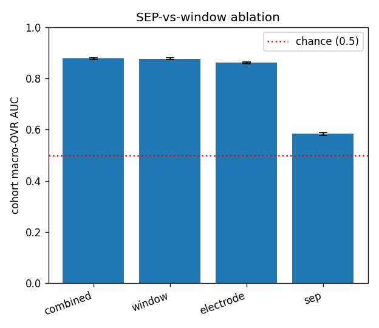

| Feature set | What's included | Macro-AUC | 3-way accuracy |
| --- | --- | --- | --- |
| **Combined** | everything (scalp + brain-source + foot-SEP) | **0.878** | 73% |
| **Window** | scalp + brain-source (no foot-SEP) | 0.877 | 73% |
| **Electrode** | scalp features only (amplitude, slopes, power) | 0.862 | 71% |
| **SEP only** | just the foot-stimulation feature | 0.584 | 40% |

Two clean answers

**Does the new foot-SEP feature add anything?** No. "Combined" and "Window" score identically (0.878 vs 0.877), so once the ordinary scalp features are present, the foot-SEP is redundant — although on its own it does carry a weak signal (0.58). **Do the expensive brain-source features earn their keep?** Yes, modestly — removing them drops the score by 0.015 (0.877 → 0.862), and more tellingly it costs ~4 points of accuracy on the hard straight-vs-diagonal distinction (63/61% → 59/57%). (In an early 8-person preview this gap looked negligible; across the full cohort the brain-source contribution is small but consistent.)

The **confusion matrix** shows *where* the accuracy comes from: rows are the true state, columns are the model's guess, and the diagonal counts correct calls.

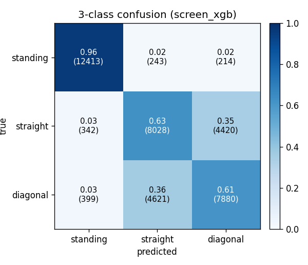

Figure 10. Three-by-three confusion matrix across all thirty-two participants. Standing is identified almost perfectly (~96% of standing epochs correct). The errors concentrate in the bottom-right block: straight and diagonal steps are most often confused *with each other* (~61–63% correct each), not with standing.

So the three states are **not** equally easy. Per-class accuracy is about **96% for standing, 63% for straight, and 61% for diagonal**. Standing is trivially separable from movement; the genuinely hard sub-problem — telling a straight step from a diagonal one — is exactly the original step-type question, and it sits modestly above its own two-way chance line.

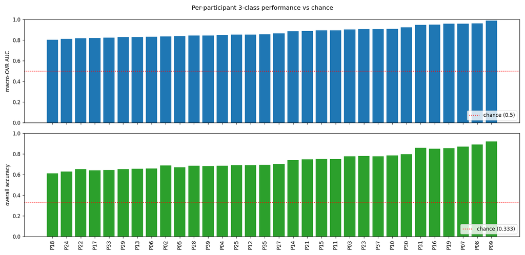

Figure 11. Each participant's own model. Top: three-class macro-AUC (chance 0.50, dashed). Bottom: overall accuracy (chance 0.333, dashed). Every participant is clearly above chance on both measures, with the usual person-to-person variation.

## 8 An honest caveat: the stimulation-rhythm confound

Read this before over-interpreting "standing"

Standing being identified almost perfectly is partly *too* easy. During standing the foot is stimulated in a steady half-second rhythm; during stepping the pulses come in a short cluster and then stop. That difference in **stimulation rhythm** — not necessarily brain state — can by itself separate standing from stepping. We actively blank the electrical-pulse artefacts before computing features, but the blanking pattern itself still differs between the states, so some of the "standing" performance may reflect the experiment's structure rather than the brain.

This is why the **straight-vs-diagonal** comparison is the scientifically clean one: both are stepping, with the identical pulse structure, so any separation there is genuine movement-related brain signal. A planned "stimulation-artefact-only" control will quantify exactly how much of the standing result is confound versus real motor state.

## 9 Summary and next steps

In plain terms: **a 2-second EEG window distinguishes standing, straight stepping, and diagonal stepping well above chance** (macro-AUC 0.88, accuracy 73% versus 33%), with an honest test. Standing is easy (with the confound caveat above); separating the two step types is the hard, meaningful part. The controlled comparison was decisive: the new foot-SEP feature adds nothing beyond the basic scalp measurements, whereas the brain-source features give a small but real boost to the hard straight-vs-diagonal distinction.

**Where this goes next:**

- **The full cohort is complete (all 32 participants).** The ablation's guidance for a production feature set: **keep the brain-source features** (they give a small, consistent lift to straight-vs-diagonal) and **drop the foot-SEP block** (redundant).
- **Run the stimulation-artefact control** to pin down how much of the standing result is the rhythm confound versus genuine motor state.
- **Focus on straight-vs-diagonal**, the confound-free core problem, and connect it back to the step-type project's findings.

## Plain-language glossary

**EEG**

Recording the brain's electrical activity with sensors on the scalp.

**Epoch / trial**

One ~2-second recording across all sensors — one example for the model.

**Motor state**

Here, one of three: standing, stepping straight, or stepping diagonally.

**Feature**

A single number summarising one aspect of an epoch.

**SEP (somatosensory evoked potential)**

The brain's small response to a touch/stimulation of the body — here, the electrical pulse to the sole of the foot.

**Macro-AUC**

The three-class performance score: for each state, how well it is separated from the other two, averaged. 0.50 = chance, 1.00 = perfect.

**Accuracy**

The fraction of epochs whose state the model gets exactly right. Chance here is 1/3 (33%).

**Ablation**

Re-running the analysis with parts of the feature set removed, to see what each part contributes.

**Confusion matrix**

A table of true state versus predicted state; the diagonal counts correct calls.

**Overfitting**

When a model memorises its training data instead of learning a general rule.

**Cross-validation**

Repeatedly holding out part of the data as an unseen test to estimate real-world performance fairly.

**XGBoost**

The model used here: hundreds of small decision trees added together, each correcting the previous ones' mistakes.

The full 32-participant cohort run of the 3-class motor-state classifier, the three-way sibling of the EEG step-type project. Per-participant nested cross-validation; cohort macro-AUC 0.878, 3-way accuracy 73% (chance 33%), inner-vs-outer gap 0.05. Figures 2–4, 7–8 are explanatory schematics shared with the step-type report; Figures 1, 5–6, 9–11 are generated from this project's own data and results. Bracketed yellow fields on the title page are placeholders to be filled in. Cohort complete (32/32).